# 4.3 Newton’s method

### Example 4.3.1(Graphical interpretation of Newton’s method)

Suppose we want to find a root of this function:

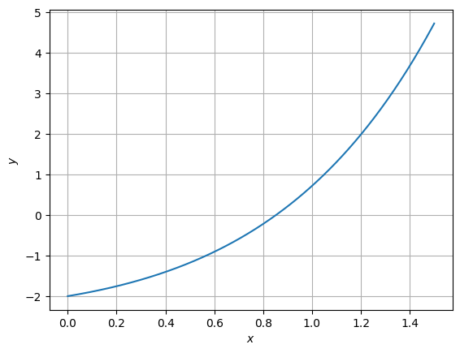

```python
import numpy as np
from numpy import exp, linspace
from matplotlib.pyplot import subplots
f = lambda x: x * exp(x) - 2
xx = linspace(0, 1.5, 400)

fig, ax = subplots()
ax.plot(xx, f(xx), label="function")
ax.grid()
ax.set_xlabel("$x$")
ax.set_ylabel("$y$");
```

From the graph, it is clear that there is a root near $x=1$.So we call that our initial guess,$x_1$.

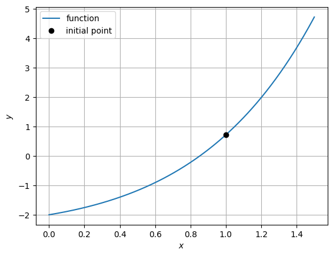

```python
x1 = 1
y1 = f(x1)
ax.plot(x1, y1, "ko", label="initial point")
ax.legend()
fig
```

Next, we can compute the tangent line at the point $(x_1 ,f(x_1))$, using the derivative.

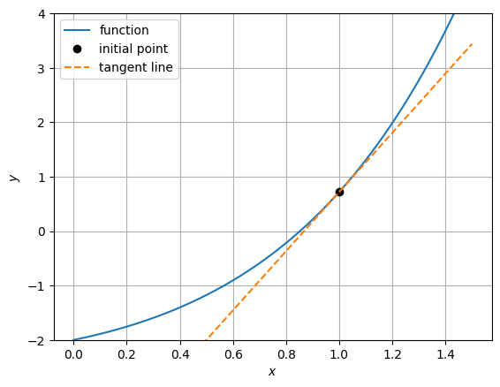

```python
df_dx = lambda x: exp(x) * (x + 1)
slope1 = df_dx(x1)
tangent1 = lambda x: y1 + slope1 * (x - x1)

ax.plot(xx, tangent1(xx), "--", label="tangent line")
ax.set_ylim(-2, 4)
ax.legend()
fig
```

In lieu of finding the root of $f$ itself, we settle for finding the root of the tangent line approximation, which is trivial. Call this $x_2$, our next approximation to the root.

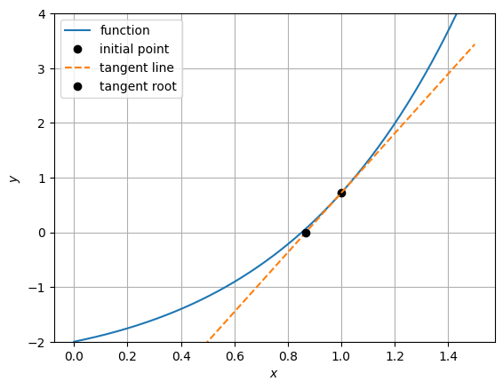

```python
x2 = x1 - y1 / slope1
ax.plot(x2, 0, "ko", label="tangent root")
ax.legend()
fig
```

```python
y2 = f(x2)
print(y2)
```

```
0.06716266657572145
```

The residual (i.e., value of $f$) is smaller than before, but not zero. So we repeat the process with a new tangent line based on the latest point on the curve.

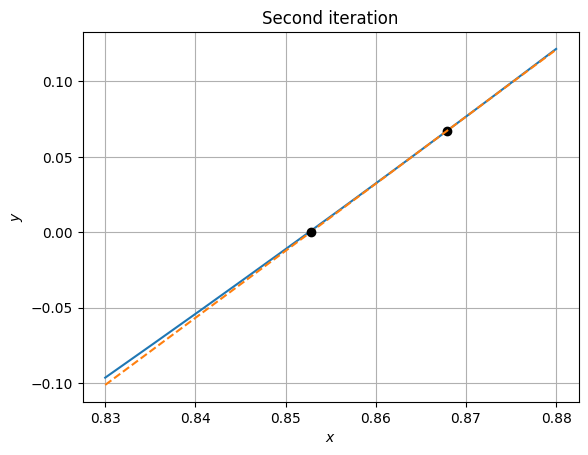

```python
from matplotlib.pyplot import plot, grid, xlabel, ylabel, title
xx = linspace(0.83, 0.88, 200)

plot(xx, f(xx))
plot(x2, y2, "ko")
grid(), xlabel("$x$"), ylabel("$y$")

slope2 = df_dx(x2)
tangent2 = lambda x: y2 + slope2 * (x - x2)
plot(xx, tangent2(xx), "--")
x3 = x2 - y2 / slope2
plot(x3, 0, "ko")
title("Second iteration");
```

```python
y3 = f(x3)
print(y3)
```

```
0.0007730906446230534
```

Judging by the residual, we appear to be getting closer to the true root each time.

Using general notation, if we have a root approximation $x_k$, we can construct a \textbf{linear model} of $f(x)$ using the classic formula for the tangent line of a differentiable function, \begin{equation} q(x) = f(x_k) + f'(x_k)(x - x_k). \tag{4.3.1} \end{equation}

Finding the root of $q(x) = 0$ is trivial. We define the next approximation by the condition $q(x_{k+1}) = 0$, which leads to the following.

$\textbf{Newton’s method}$

Given a function $f$, its derivative $f'$, and an initial value $x_1$, iteratively define \begin{equation} x_{k+1} = x_k - \frac{f(x_k)}{f'(x_k)}, \quad k = 1, 2, \ldots. \tag{4.3.2} \end{equation} Return the sequence $\{x_k\}$.

## Convergence

$\textbf{Definition 4.3.2 (Quadratic convergence)}$

Suppose a sequence $x_k$ approaches limit $x^*$. If the error sequence $\varepsilon_k = x_k - x^*$ satisfies \begin{equation} \lim_{k \to \infty} \frac{|\varepsilon_{k+1}|}{|\varepsilon_k|^2} = L \tag{4.3.8} \end{equation} for a positive constant $L$, then the sequence has \textbf{quadratic convergence} to the limit.

Recall that linear convergence is identifiable by trending toward a straight line on a log-linear plot of the error. When the convergence is quadratic, no such straight line exists—the convergence keeps getting steeper. As a numerical test, note that $|\varepsilon_{k+1}| \approx K |\varepsilon_k|^2$ implies that as $k \to \infty$, \begin{align} \log |\varepsilon_{k+1}| &\approx 2 \log |\varepsilon_k| + L, \\ \frac{\log |\varepsilon_{k+1}|}{\log |\varepsilon_k|} &\approx 2 + \frac{L}{\log |\varepsilon_k|} \to 2. \tag{4.3.9} \end{align}

### Example 4.3.2(Convergence of Newton’s method)

We again look at finding a solution of $x e^x = 2$ near $x = 1$. To apply Newton’s method, we need to calculate values of both the residual function $f$ and its derivative.

```python
f = lambda x: x * exp(x) - 2
df_dx = lambda x: exp(x) * (x + 1)
```

```python
from scipy.optimize import root_scalar
r = root_scalar(f, bracket=[0.8, 1.0]).root
print(r)
```

```
0.8526055020137255
```

We use $x_1 = 1$ as a starting guess and apply the iteration in a loop, storing the sequence of iterates in a vector.

```python
from numpy import ones
x = ones(5)
for k in range(4):
    x[k + 1] = x[k] - f(x[k]) / df_dx(x[k])

print(x)
```

```
[1.         0.86787944 0.85278337 0.85260553 0.8526055 ]
```

Here is the sequence of errors.

```python
err = x - r
print(err)
```

```
[1.47394498e-01 1.52739392e-02 1.77871403e-04 2.43551965e-08
 4.44089210e-16]
```

The exponents in the scientific notation definitely suggest a squaring sequence. We can check the evolution of the ratio in (4.3.9).

```python
from numpy import log
logerr = log(abs(err))
for i in range(len(err) - 1):
    print(logerr[i+1] / logerr[i])
```

```
2.1840144823399648
2.064863881067786
2.030299689916648
2.01651205997716
```

The clear convergence to 2 above constitutes good evidence of quadratic convergence.

- The residual function $f$ has to have enough continuous derivatives to make the Taylor series expansion valid.  
  Often this is stated as $f$ having sufficient *smoothness*.  
  This is usually not a problem.
- We required $f'(r) \neq 0$, meaning that $r$ must be a simple root.
- We assumed that the sequence converged, which is not easy to guarantee in any particular case.  
  In fact, finding a starting value from which the Newton iteration converges is often the most challenging part of a root-finding problem.  
  We will try to deal with this issue in *Quasi-Newton methods*.

## Implementation

### Newton’s method

```python
def newton(f, dfdx, x1):
    """
    newton(f, dfdx, x1)

    Use Newton's method to find a root of f starting from x1, where dfdx is the
    derivative of f. Returns a vector of root estimates.
    """
    # Operating parameters.
    eps = np.finfo(float).eps
    funtol = 100 * eps
    xtol = 100 * eps
    maxiter = 40

    x = np.zeros(maxiter)
    x[0] = x1
    y = f(x1)
    dx = np.inf  # for initial pass below
    k = 0

    while (abs(dx) > xtol) and (abs(y) > funtol) and (k < maxiter):
        dydx = dfdx(x[k])
        dx = -y / dydx  # Newton step
        x[k + 1] = x[k] + dx  # new estimate

        k = k + 1
        y = f(x[k])

    if k == maxiter:
        warnings.warn("Maximum number of iterations reached.")

    return x[:k+1]
```

*Function 4.3.1* also deals with a thorny practical issue: how to stop the iteration.  
It adopts a three-part criterion.

First, it monitors the difference between successive root estimates,  
$|x_k - x_{k-1}|$, which is used as a stand-in for the unknown error $|x_k - r|$.

In addition, it monitors the residual $|f(x_k)|$, which is equivalent to the backward error and more realistic to control in badly conditioned problems (see *The rootfinding problem*).

If either of these quantities is considered to be sufficiently small, the iteration ends.  
Finally, we need to protect against the possibility of a nonconvergent iteration, so the procedure terminates with a warning if a maximum number of iterations is exceeded.

### Example 4.3.3(Using Newton’s method)

Suppose we want to evaluate the inverse of the function $h(x) = e^x - x$.  
This means solving $y = h(x)$, or $h(x) - y = 0$, for $x$ when $y$ is given.

That equation has no solution in terms of elementary functions.  
If a value of $y$ is given numerically, though, we simply have a root-finding problem for

$$ f(x) = e^x - x - y. $$

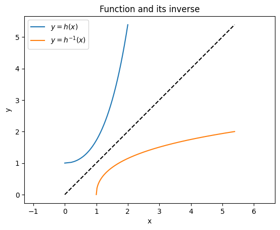

```python
from numpy import exp, linspace, zeros
from matplotlib.pyplot import plot, grid, xlabel, ylabel, title, legend, axhline ,axis
h = lambda x: exp(x) - x
dh_dx = lambda x: exp(x) - 1
y_ = linspace(h(0), h(2), 200)
x_ = zeros(y_.shape)
for (i, y) in enumerate(y_):
    f = lambda x: h(x) - y
    df_dx = lambda x: dh_dx(x)
    x = newton(f, df_dx, y)
    x_[i] = x[-1]

plot(x_, y_, label="$y=h(x)$")
plot(y_, x_, label="$y=h^{-1}(x)$")
plot([0, max(y_)], [0, max(y_)], 'k--', label="")
title("Function and its inverse")
xlabel("x"), ylabel("y"), axis("equal")
ax.grid()
legend();
```

# 4.4 Interpolation-based methods

### Example 4.4.1(Graphical interpretation of the secant method)

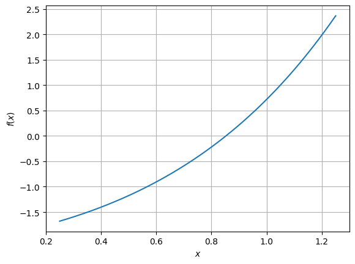

```python
f = lambda x: x * exp(x) - 2
xx = linspace(0.25, 1.25, 400)

fig, ax = subplots()
ax.plot(xx, f(xx), label="function")
ax.set_xlabel("$x$")
ax.set_ylabel("$f(x)$")
ax.grid();
```

From the graph, it’s clear that there is a root near $x=1$. To be more precise, there is a root in the interval $[ 0.5 , 1 ]$. So let us take the endpoints of that interval as two initial approximations.

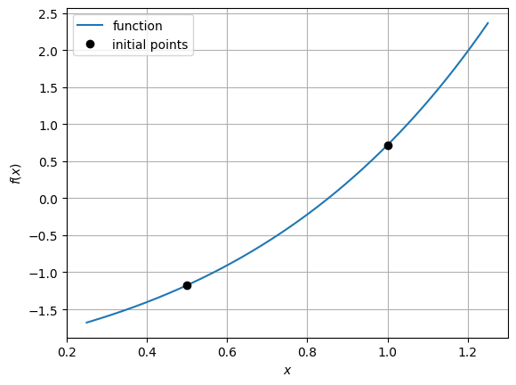

```python
x1 = 1
y1 = f(x1)
x2 = 0.5
y2 = f(x2)
ax.plot([x1, x2], [y1, y2], "ko", label="initial points")
ax.legend()
fig
```

Instead of constructing the tangent line by evaluating the derivative, we can construct a linear model function by drawing the line between the two points $(x_1  ,f(x_1))$ and $(x_2  ,f(x_2))$. This is called a secant line.

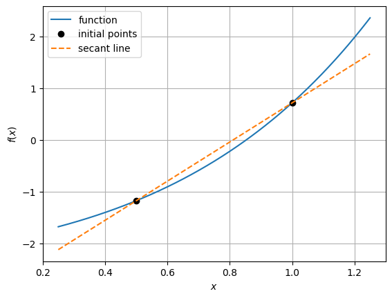

```python
slope2 = (y2 - y1) / (x2 - x1)
secant2 = lambda x: y2 + slope2 * (x - x2)
ax.plot(xx, secant2(xx), "--", label="secant line")
ax.legend()
fig
```

As before, the next root estimate in the iteration is the root of this linear model.

```
-0.17768144843679456
```

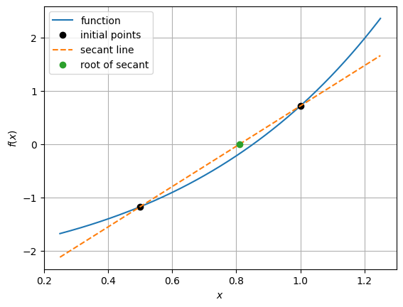

```python
x3 = x2 - y2 / slope2
ax.plot(x3, 0, "o", label="root of secant")
y3 = f(x3)
print(y3)
ax.legend()
fig
```

For the next linear model, we use the line through the two most recent points. The next iterate is the root of that secant line, and so on.

```python
slope3 = (y3 - y2) / (x3 - x2)
x4 = x3 - y3 / slope3
print(f(x4))
```

```
0.05718067370113333
```

**Definition 4.4.1 (Secant method)**

Given function $f$ and two initial values $x_1$ and $x_2$, define

$$ x_{k+1} = x_k - \frac{f(x_k)(x_k - x_{k-1})}{f(x_k) - f(x_{k-1})}, \quad k = 2, 3, \ldots. \tag{4.4.2} $$

Return the sequence $\{x_k\}$.

### Secant method

```python
def secant(f, x1, x2):
    """
    secant(f, x1, x2)

    Use the secant method to find a root of f starting from x1 and x2. Returns a
    vector of root estimates.
    """
    # Operating parameters.
    eps = np.finfo(float).eps
    funtol = 100 * eps
    xtol = 100 * eps
    maxiter = 40

    x = np.zeros(maxiter)
    x[:2] = [x1, x2]
    y1 = f(x1)
    y2 = 100
    dx = np.inf  # for initial pass below
    k = 1

    while (abs(dx) > xtol) and (abs(y2) > funtol) and (k < maxiter):
        y2 = f(x[k])
        dx = -y2 * (x[k] - x[k - 1]) / (y2 - y1)  # secant step
        x[k + 1] = x[k] + dx  # new estimate

        k = k + 1
        y1 = y2  # current f-value becomes the old one next time

    if k == maxiter:
        warnings.warn("Maximum number of iterations reached.")
    return x[:k+1]
```

## Convergence

**Definition 4.4.2 (Superlinear convergence)**

Suppose a sequence $x_k$ approaches limit $x^*$.  
If the error sequence $\varepsilon_k = x_k - x^*$ satisfies

$$ \lim_{k \to \infty} \frac{|\varepsilon_{k+1}|}{|\varepsilon_k|^{\alpha}} = L \tag{4.4.7} $$

for constants $\alpha > 1$ and $L > 0$, then the sequence has  
**superlinear convergence** with rate $\alpha$.

Quadratic convergence is a particular case of superlinear convergence.  
Roughly speaking, we expect

$$ \log |\varepsilon_{k+1}| \approx \alpha (\log |\varepsilon_k|) + \log L, $$

and

$$ \frac{\log |\varepsilon_{k+1}|}{\log |\varepsilon_k|} \approx \alpha + \frac{\log L}{\log |\varepsilon_k|} \to \alpha, \quad \text{as } k \to \infty. \tag{4.4.8} $$

```python
###  Example 4.4.2(Convergence of the secant method)
```

We check the convergence of the secant method from Example 4.4.1.

```python
f = lambda x: x * exp(x) - 2
x = secant(f, 1, 0.5)
print(x)
```

```
[1.         0.5        0.81037177 0.86563193 0.85217802 0.85260123
 0.8526055  0.8526055  0.8526055 ]
```

We don’t know the exact root, so we use root_scalar to get a substitute.

```python
from scipy.optimize import root_scalar
r = root_scalar(f, bracket=[0.5, 1]).root
print(r)
```

```
0.8526055020137254
```

Here is the sequence of errors.

```python
err = r - x
print(err)
```

```
[-1.47394498e-01  3.52605502e-01  4.22337271e-02 -1.30264253e-02
  4.27479941e-04  4.26991559e-06 -1.40547707e-09  4.55191440e-15
  0.00000000e+00]
```

It’s not easy to see the convergence rate by staring at these numbers. We can use (4.4.8) to try to expose the superlinear convergence rate.

```python
logerr = log(abs(err))
for i in range(len(err) - 2):
    print(logerr[i+1] / logerr[i])
```

```
0.5444386280277934
3.0358017547194565
1.3716940021941457
1.7871469297607958
1.593780475055435
1.6485786717829443
1.62014464365765
```

As expected, this settles in at around 1.618.

## Inverse interpolation

At each iteration, the secant method constructs a linear model function that interpolates  
the two most recently found points on the graph of $f$. Two points determine a straight line,  
so this seems like a sensible choice. But as the iteration progresses, why use only the **two**  
most recent points? What would it mean to use more of them?

If we interpolate through three points by a polynomial, we get a unique quadratic function.  
Unfortunately, a parabola may have zero, one, or two crossings of the $x$-axis,  
potentially leaving some doubt as to how to define the next root estimate.  
On the other hand, if we turn a parabola on its side, we get a graph that  
intersects the $x$-axis exactly once, which is ideal for defining the next root estimate.

This leads to the idea of defining $q(y)$ as the quadratic interpolant to the points  
$(y_{k-2}, x_{k-2})$, $(y_{k-1}, x_{k-1})$, and $(y_k, x_k)$,  
where $y_i = f(x_i)$ for all $i$, and setting $x_{k+1} = q(0)$.

The process defined in this way (given three initial estimates)  
is called **inverse quadratic interpolation**.

### Example 4.4.3(Inverse quadratic interpolation)

Here we look for a root of $x+cos(10x)$ that is close to 1.

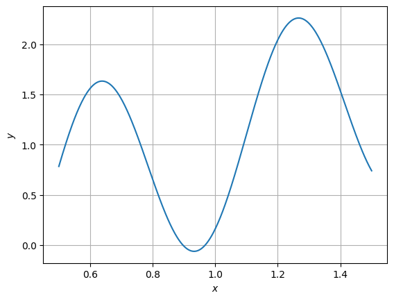

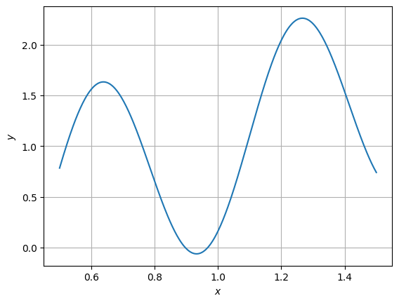

```python
from numpy import linspace, cos
from matplotlib.pyplot import subplots, xlabel, ylabel
f = lambda x: x + cos(10 * x)
xx = linspace(0.5, 1.5, 400)
fig, ax = subplots()
ax.plot(xx, f(xx), label="function")
ax.grid()
xlabel("$x$"), ylabel("$y$")
fig
```

We choose three values to get the iteration started.

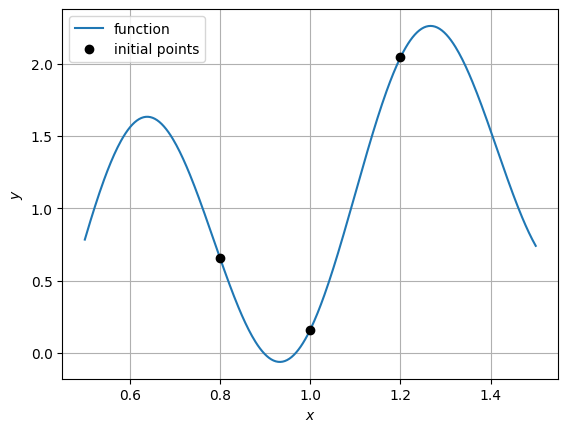

```python
from numpy import array
from matplotlib.pyplot import figure, show
x = array([0.8, 1.2, 1])
y = f(x)
ax.plot(x, y, "ko", label="initial points")
ax.legend()
fig
```

If we were using forward interpolation, we would ask for the polynomial interpolant of $y$ as a function of $x$. But that parabola has no real roots.

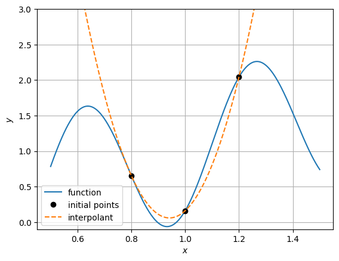

```python
from numpy import polyfit, poly1d
q = poly1d(polyfit(x, y, 2))  # interpolating polynomial
ax.plot(xx, q(xx), "--", label="interpolant")
ax.set_ylim(-0.1, 3), ax.legend()
fig
```

To do inverse interpolation, we swap the roles of $x$ and $y$ in the interpolation.

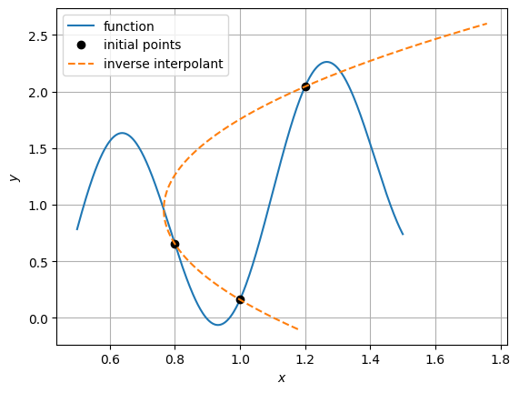

```python
plot(xx, f(xx), label="function")
plot(x, y, "ko", label="initial points")

q = poly1d(polyfit(y, x, 2))  # inverse interpolating polynomial
yy = linspace(-0.1, 2.6, 400)
plot(q(yy), yy, "--", label="inverse interpolant")

grid(), xlabel("$x$"), ylabel("$y$")
legend();
```

We seek the value of $x$ that makes $y$ zero. This means evaluating $q$ at zero.

```python
from numpy import hstack
x = hstack([x, q(0)])
y = hstack([y, f(x[-1])])
print("x:", x, "\ny:", y)
```

```
x: [0.8        1.2        1.         1.10398139]
y: [0.65449997 2.04385396 0.16092847 1.14820652]
```

We repeat the process a few more times.

```python
for k in range(6):
    q = poly1d(polyfit(y[-3:], x[-3:], 2))
    x = hstack([x, q(0)])
    y = hstack([y, f(x[-1])])
print(f"final residual is {y[-1]:.2e}")
```

```
final residual is 1.53e-14
```

Here is the sequence of errors.

```python
from scipy.optimize import root_scalar
r = root_scalar(f, bracket=[0.9, 1]).root
err = x - r
print(err)
```

```
[-1.67888402e-01  2.32111598e-01  3.21115982e-02  1.36092984e-01
  1.53473435e-02  3.26831473e-03  4.61743614e-04  6.29584770e-06
  3.43903639e-09  6.39488462e-14]
```

The error seems to be superlinear, but subquadratic:

```python
logerr = log(abs(err))
for i in range(len(err) - 1):
    print(logerr[i+1] / logerr[i])
```

```
0.818477543986624
2.354297090262193
0.5800188694773647
2.0942526256501544
1.3702985897216806
1.3419282845367289
1.559223883556642
1.6273123343540232
1.5589376401004071
```

# 4..5 Newton for nonlinear systems

With a method in hand for constructing a linear model for the vector system $\mathbf{f}(\mathbf{x})$,  
we can generalize Newton’s method. Specifically, at a root estimate $\mathbf{x}_k$,  
we set $\mathbf{h} = \mathbf{x} - \mathbf{x}_k$ in (4.5.7) and get

$$ \mathbf{f}(\mathbf{x}) \approx \mathbf{q}(\mathbf{x}) = \mathbf{f}(\mathbf{x}_k) + \mathbf{J}(\mathbf{x}_k)(\mathbf{x} - \mathbf{x}_k). \tag{4.5.8} $$

We define the next iteration value $\mathbf{x}_{k+1}$ by requiring $\mathbf{q}(\mathbf{x}_{k+1}) = 0$,

$$ \mathbf{0} = \mathbf{f}(\mathbf{x}_k) + \mathbf{J}(\mathbf{x}_k)(\mathbf{x}_{k+1} - \mathbf{x}_k), \tag{4.5.9} $$

which can be rearranged into

$$ \mathbf{x}_{k+1} = \mathbf{x}_k - [\mathbf{J}(\mathbf{x}_k)]^{-1}\mathbf{f}(\mathbf{x}_k). \tag{4.5.10} $$

Note that $\mathbf{J}^{-1}\mathbf{f}$ now plays the role that $f/f'$ had in the scalar case;  
in fact, the two are the same in one dimension.  
In computational practice, however, we don’t compute matrix inverses directly.

**Algorithm 4.5.1 (Multidimensional Newton’s method)**

Given $\mathbf{f}$ and a starting value $\mathbf{x}_1$, for each $k = 1, 2, 3, \ldots$:

1. Compute $\mathbf{y}_k = \mathbf{f}(\mathbf{x}_k)$ and $\mathbf{A}_k = \mathbf{f}'(\mathbf{x}_k)$.
2. Solve the linear system $\mathbf{A}_k \mathbf{s}_k = -\mathbf{y}_k$ for the **Newton step** $\mathbf{s}_k$.
3. Let $\mathbf{x}_{k+1} = \mathbf{x}_k + \mathbf{s}_k$.

An extension of our series analysis of the scalar Newton’s method shows that  
the vector version is also **quadratically convergent** in any vector norm,  
under suitable circumstances and when the iteration converges at all.

### Function 4.5.2 (newtonsys)

```python
def newtonsys(f, jac, x1):
    """
        newtonsys(f, jac, x1)

    Use Newton's method to find a root of a system of equations, starting from x1. The
    function f should return the residual vector, and the function jac should return
    the Jacobian matrix. Returns root estimates as a matrix, one estimate per column.
    """
    # Operating parameters.
    funtol = 1000 * np.finfo(float).eps
    xtol = 1000 * np.finfo(float).eps
    maxiter = 40

    x = np.zeros((maxiter, len(x1)))
    x[0] = x1
    y, J = f(x1), jac(x1)
    dx = 10.0  # for initial pass below
    k = 0

    while (norm(dx) > xtol) and (norm(y) > funtol) and (k < maxiter):
        dx = -lstsq(J, y)[0]  # Newton step
        x[k+1] = x[k] + dx

        k = k + 1
        y, J = f(x[k]), jac(x[k])

    if k == maxiter:
        warnings.warn("Maximum number of iterations reached.")
    return x[:k+1]
```

### Example 4.5.3(Convergence of Newton’s method for systems)

A system of nonlinear equations is defined by its residual and Jacobian.

```python
def func(x):
    return array([
        exp(x[1] - x[0]) - 2,
        x[0] * x[1] + x[2],
        x[1] * x[2] + x[0]**2 - x[1]
    ])

def jac(x):
    return array([
            [-exp(x[1] - x[0]), exp(x[1] - x[0]), 0],
            [x[1], x[0], 1],
            [2 * x[0], x[2] - 1, x[1]],
    ])
```

Our initial guess at a root is the origin.

```python
from numpy.linalg import lstsq
from numpy.linalg import norm
x1 = zeros(3)
x = newtonsys(func, jac, x1)
print(x)
```

```
[[ 0.00000000e+00  0.00000000e+00  0.00000000e+00]
 [-1.00000000e+00 -1.20292797e-16  0.00000000e+00]
 [-5.78586294e-01  1.57172588e-01  1.57172588e-01]
 [-4.63138615e-01  2.30903685e-01  1.15452497e-01]
 [-4.58026868e-01  2.35120714e-01  1.07713160e-01]
 [-4.58033281e-01  2.35113900e-01  1.07689991e-01]
 [-4.58033281e-01  2.35113900e-01  1.07689991e-01]]
```

The output has one row per iteration, so the last row contains the final Newton estimate. Let’s compute its residual.

```python
r = x[-1]
f = func(r)
print("final residual:", f)
```

```
final residual: [0. 0. 0.]
```

Let’s check the convergence rate:

```python
logerr = [log(norm(x[k] - r)) for k in range(x.shape[0] - 1)]
for k in range(len(logerr) - 1):
    print(logerr[k+1] / logerr[k])
```

```
0.7937993447128697
3.6959808854483067
2.4326597889977193
2.3110932374367614
2.132541106999156
```

The ratio is apparently converging toward 2, as expected for quadratic convergence.

# Quasi-Newton methods

## Jacobian by finite differences

In the scalar case, we found an easy alternative to a direct evaluation of the derivative.  
In retrospect, we may interpret the secant formula (4.4.2) as the Newton formula (4.3.2)  
with $f'(x_k)$ replaced by the difference quotient

$$ \frac{f(x_k) - f(x_{k-1})}{x_k - x_{k-1}}. \tag{4.6.1} $$

If the sequence of $x_k$ values converges to a root $r$, then this quotient converges to $f'(r)$.

In the system case, replacing the Jacobian evaluation is more complicated:  
derivatives are needed with respect to $n$ variables, not just one.  
From (4.5.3), we note that the $j$th column of the Jacobian is

$$ \mathbf{J}(\mathbf{x}) \mathbf{e}_j = \begin{bmatrix} \frac{\partial f_1}{\partial x_j} \\ \frac{\partial f_2}{\partial x_j} \\ \vdots \\ \frac{\partial f_n}{\partial x_j} \end{bmatrix}. \tag{4.6.2} $$

(As always, $\mathbf{e}_j$ represents the $j$th column of the identity matrix, here in $n$ dimensions.)  
Inspired by (4.6.1), we can replace the differentiation with a quotient involving  
a change in only $x_j$ while the other variables remain fixed:

$$ \mathbf{J}(\mathbf{x}) \mathbf{e}_j \approx \frac{\mathbf{f}(\mathbf{x} + \delta \mathbf{e}_j) - \mathbf{f}(\mathbf{x})}{\delta}, \quad j = 1, \ldots, n. \tag{4.6.3} $$

For reasons explained in Chapter 5, $\delta$ is usually chosen close to $\sqrt{\epsilon}$,  
where $\epsilon$ represents the expected noise or uncertainty level in evaluation of $\mathbf{f}$.  
If the only source of noise is floating-point roundoff, then $\delta \approx \sqrt{\epsilon_{\text{mach}}}$.

The finite-difference formula (4.6.3) is implemented by *Function 4.6.1*.

### Function 4.6.1.Finite differences for Jacobian

```python
def fdjac(f, x0, y0):
    """
    fdjac(f,x0,y0)

    Compute a finite-difference approximation of the Jacobian matrix for f at x0,
    where y0=f(x0) is given.
    """

    delta = np.sqrt(np.finfo(float).eps)  # FD step size
    m, n = len(y0), len(x0)
    J = np.zeros((m, n))
    I = np.eye(n)
    for j in range(n):
        J[:, j] = (f(x0 + delta * I[:, j]) - y0) / delta
    return J
```

**Algorithm 4.6.2 (Levenberg’s method)**

Given $\mathbf{f}$, a starting value $\mathbf{x}_1$, and a scalar $\lambda$, for each $k = 1, 2, 3, \ldots$

1. Compute $\mathbf{y}_k = \mathbf{f}(\mathbf{x}_k)$, and let $\mathbf{A}_k$ be an exact or approximate Jacobian matrix.
2. Solve the linear system
   $$ (\mathbf{A}_k^{T}\mathbf{A}_k + \lambda \mathbf{I}) \mathbf{s}_k = -\mathbf{A}_k^{T}\mathbf{f}_k. $$
3. Let $\hat{\mathbf{x}} = \mathbf{x}_k + \mathbf{s}_k$.
4. If the residual is reduced at $\hat{\mathbf{x}}$, then let $\mathbf{x}_{k+1} = \hat{\mathbf{x}}$.
5. Update $\lambda$ and update $\mathbf{A}_k$ to $\mathbf{A}_{k+1}$.

Some justification of (4.6.9) comes from considering extreme cases for $\lambda$.  
If $\lambda = 0$, then

$$ \mathbf{A}_k^T \mathbf{A}_k \mathbf{s}_k = -\mathbf{A}_k^T \mathbf{f}_k, \tag{4.6.10} $$

which is equivalent to the definition of the usual linear model  
(i.e., Newton or quasi-Newton step) (4.6.5).  
On the other hand, as $\lambda \to \infty$, Equation (4.6.9) approaches

$$ \lambda \mathbf{s}_k = -\mathbf{A}_k^T \mathbf{f}_k. \tag{4.6.11} $$

To interpret this equation, define the scalar residual function

$$ \phi(\mathbf{x}) = \mathbf{f}(\mathbf{x})^T \mathbf{f}(\mathbf{x}) = \|\mathbf{f}(\mathbf{x})\|^2. \tag{4.6.12} $$

Finding a root of $\mathbf{f}$ is equivalent to minimizing $\phi$.  
A calculation shows that the gradient of $\phi$ is

$$ \nabla \phi(\mathbf{x}) = 2 \mathbf{J}(\mathbf{x})^T \mathbf{f}(\mathbf{x}). \tag{4.6.13} $$

Hence, if $\mathbf{A}_k = \mathbf{J}(\mathbf{x}_k)$,  
then $\mathbf{s}_k$ from (4.6.11) is in the opposite direction  
from the gradient vector.

In vector calculus, you learn that this direction is the one of most rapid decrease —  
or **steepest descent**.  
A small enough step in this direction is guaranteed, in all but pathological cases,  
to decrease $\phi$, which is exactly what we want from a backup plan.

In effect, the $\lambda$ parameter in (4.6.9) allows a smooth transition between  
the pure Newton step (for rapid convergence near a root)  
and a small step in the gradient descent direction,  
which guarantees progress for the iteration when we are far from a root.

## Implementation

### Function 4.6.3 Levenberg’s method

```python
def levenberg(f, x1, tol=1e-12):
    """
    levenberg(f,x1,tol)

    Use Levenberg's quasi-Newton iteration to find a root of the system f,
    starting from x1, with tol as the stopping tolerance in both step size and residual norm. Returns root estimates as a matrix, one estimate per column.
    """

    # Operating parameters.
    ftol = tol
    xtol = tol
    maxiter = 40

    n = len(x1)
    x = np.zeros((maxiter+1, n))
    x[0] = x1
    fk = f(x1)
    k = 0
    s = 10.0
    Ak = fdjac(f, x[0], fk)  # start with FD Jacobian
    jac_is_new = True

    lam = 10
    while (norm(s) > xtol) and (norm(fk) > ftol) and (k < maxiter):
        # Compute the proposed step.
        B = Ak.T @ Ak + lam * np.eye(n)
        z = Ak.T @ fk
        s = -lstsq(B, z)[0]

        xnew = x[k] + s
        fnew = f(xnew)

        # Do we accept the result?
        if norm(fnew) < norm(fk):  # accept
            y = fnew - fk
            x[k + 1] = xnew
            fk = fnew
            k = k + 1

            lam = lam / 10  # get closer to Newton
            # Broyden update of the Jacobian.
            Ak = Ak + np.outer(y - Ak @ s, s / np.dot(s, s))
            jac_is_new = False
        else:  # don't accept
            # Get closer to steepest descent.
            lam = lam * 4
            # Re-initialize the Jacobian if it's out of date.
            if not jac_is_new:
                Ak = fdjac(f, x[k], fk)
                jac_is_new = True

    if norm(fk) > 1e-3:
        warnings.warn("Iteration did not find a root.")
    return x[:k+1]
```

### Example 4.6.1(Using Levenberg’s method)

To solve a nonlinear system, we need to code only the function defining the system, and not its Jacobian.

```python
def func(x):
    return array([
        exp(x[1] - x[0]) - 2,
        x[0] * x[1] + x[2],
        x[1] * x[2] + x[0]**2 - x[1]
    ])
```

In all other respects usage is the same as for the newtonsys function.

```python
x1 = zeros(3)
x = levenberg(func, x1)
print(f"Took {len(x) - 1} iterations.")
```

```
Took 11 iterations.
```

It’s always a good idea to check the accuracy of the root, by measuring the residual (backward error).

```python
r = x[-1]
print("backward error:", norm(func(r)))
```

```
backward error: 1.2708308198538738e-13
```

Looking at the convergence in norm, we find a convergence rate between linear and quadratic, like with the secant method:

```python
logerr = [log(norm(x[k] - r)) for k in range(len(x) - 1)]
for k in range(len(logerr) - 1):
    print(logerr[k+1] / logerr[k])
```

```
1.3488093916747848
2.6294109965748804
1.4519728849832478
1.3970235480592696
1.2898554702766942
1.273302844195005
1.4587586885825041
1.5234698304213956
1.1687771474875415
1.1579168503648603
```